# The SIR-model applied to the Corona-pandemic

```python
import numpy as np
from matplotlib import pyplot as plt
from scipy.integrate import solve_ivp
%matplotlib inline
```

## Theory

In epidemiology, the SIR-model is a simple compartmental model that can be applied to an outbreak like the Corona-pandemic.

This model distinguishes Susceptible, Infected, and Recovered (or Removed) fractions of the population. Susceptible people can get infected, and infected persons eventually recover (or die), but do not become infected again.

[figure not shown]

- The fraction that newly catches the disease is proportional to both the available susceptible fraction that can acquire the disease ($S$) and the infected fraction that can transfer the disease ($I$): $[S \rightarrow I] = \alpha \cdot S \cdot I$, where $\alpha$ is the *infection rate*.
- The population fraction that recovers (or dies) is proportional to only the fraction of infected people itself ($I$): $[I \rightarrow R] = \beta \cdot I$, where $\beta$ is the *recovery rate*.

Thus, we obtain a set of differential equations

$$ \begin{aligned} \frac{\text{d}}{\text{d}t}S &= -\alpha \cdot S \cdot I \\ \frac{\text{d}}{\text{d}t}I &= +\alpha \cdot S \cdot I - \beta \cdot I \\ \frac{\text{d}}{\text{d}t}R &= +\beta \cdot I \end{aligned} $$

Because $S$, $I$, and $R$ are fractions, $0 \leq S,I,R \leq 1$, and $S+I+R=1$.

For Covid-19, estimated infection and recovery rates are not well known, but during the initial phases of the pandemic these amounted to approximately $\alpha = 0.25$ day<sup>-1</sup> and $\beta = 0.10$ day<sup>-1</sup>.

```python
alpha = 0.25
beta = 0.10
```

## Step 1: Modelling recovery

Starting from a hypothetical population that is 100% infected, we can model the recovery of patients by calculating for each day how many people recover, and transferring these from the Infected to the Recovered fraction.

We maintain lists to keep track of the numbers each day.

```python
I = 1.000
R = 0.000

Ilist = []
Rlist = []

for day in range(150):

    Ilist.append(I)
    Rlist.append(R)

    recoveries = beta * I
    I -= recoveries
    R += recoveries
```

Next we plot the results. We see that the infected population gradually recovers according to an exponential relationship.

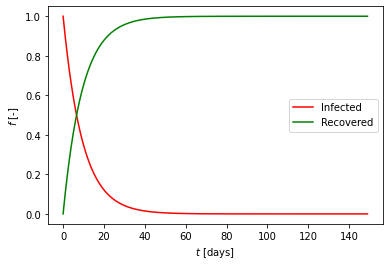

```python
plt.plot(Ilist, '-r', label='Infected')
plt.plot(Rlist, '-g', label='Recovered')
plt.xlabel('$t$ [days]'); plt.ylabel('$f$ [-]')
plt.legend(); plt.show()
```

## Step 2: Modelling infections

Now it is easy to add infections in a similar fashion. Below, we start with a predominantly healthy but susceptible population with a tiny fraction of 1‰ infected people.

```python
S = 0.999
I = 0.001
R = 0.000

Slist = []
Ilist = []
Rlist = []

for day in range(150):

    Slist.append(S)
    Ilist.append(I)
    Rlist.append(R)

    infections = alpha * S * I
    S -= infections
    I += infections

    recoveries = beta * I
    I -= recoveries
    R += recoveries
```

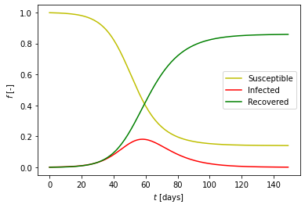

```python
plt.plot(Slist, '-y', label='Susceptible')
plt.plot(Ilist, '-r', label='Infected')
plt.plot(Rlist, '-g', label='Recovered')
plt.xlabel('$t$ [days]'); plt.ylabel('$f$ [-]')
plt.legend(); plt.show()
```

## Step 3: Numerical integration of differential equations

The chosen approach is somewhat inaccurate. For instance, we determine the number of patients day-by-day, but this is inaccurate since the number of patients will change over the course of that day. More advanced methods to compute a more accurate solution are available. We can exploit some standard functions from the `scipy` module to achieve this.

The `solve_ivp()` function requires the differential equation to be provided in the form of a single function. Therefore, we need to combine the $S$, $I$, and $R$ values into a three-element vector-quantity $\boldsymbol{v} = \left[ S, I, R \right]^\text{T}$. The three differential equations can then be combined into a single equation:

$$ \frac{\text{d}}{\text{d}t}\boldsymbol{v} = \left[ \begin{array}{c} -\alpha \cdot v_1 \cdot v_2 \\ +\alpha \cdot v_1 \cdot v_2 - \beta \cdot v_2 \\ +\beta \cdot v_2 \end{array} \right] $$

```python
# Define model
def SIRmodel(t, v):
    return [
            - alpha * v[0] * v[1],
            + alpha * v[0] * v[1] - beta * v[1],
            + beta * v[1]
           ]
```

We furthermore provide the initial values and time points that we wish to calculate, and run the integration. The resulting plot looks almost (but not exactly) the same compared to the solution we found with our crude stepwise integration.

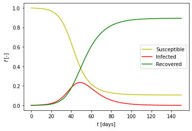

```python
fromto = (0.0, 150.0)
start = [0.999, 0.001, 0.000]
times = np.linspace(0.0, 150.0, 151)

solution = solve_ivp(SIRmodel, fromto, start, t_eval=times)

plt.plot(solution.t, solution.y[0], '-y', label='Susceptible')
plt.plot(solution.t, solution.y[1], '-r', label='Infected')
plt.plot(solution.t, solution.y[2], '-g', label='Recovered')
plt.xlabel('$t$ [days]'); plt.ylabel('$f$ [-]')
plt.legend(); plt.show()
```